# Anemia en infantes y mujeres

Authors

Colque Ordoñez, Patrick Fabrizio

Rejas Albujar, Alejandro David

Escobar Núñez, Alejandro Ismael

[figure not shown]

# **Análisis de los casos de anemia en infantes y mujeres de 12 a 49 años en el Perú en el año 2022**

## 1. Introducción

### 1.1 Relevancia

La anemia es un problema de salud pública de gran relevancia en nuestro país. La falta de hemoglobina en la sangre puede tener consecuencias graves, especialmente en niños y madres. Además, la anemia puede afectar el desarrollo físico y cognitivo de los niños y aumentar el riesgo de complicaciones en el embarazo para las madres; por lo tanto, comprender la prevalencia y severidad de la anemia en estos grupos es esencial para abordar adecuadamente este problema de salud en el país.

### 1.2 Objetivos

- Describir los casos de anemia y su severidad en niños y mujeres en el Perú en el año 2022.
- Analizar el índice de anemia en las diversas regiones del Perú en el año 2022.
- Describir las características sociales de los grupos vulnerables (niños y mujeres) a la anemia en el Perú en el año 2022.

### 1.3 Contexto

En el mes de mayo del año 2022, se llevó a cabo en nuestro país la Encuesta Demográfica y de Salud Familiar, un estudio que recopiló datos de una muestra representativa de viviendas en todo el territorio peruano. Este estudio se basó en tres cuestionarios diseñados específicamente: uno dirigido a todos los miembros de cada hogar, otro enfocado en mujeres cuyas edades se encontraban en el rango de 12 a 49 años, y un tercero destinado a individuos de 15 años o más.

En el contexto de esta encuesta, se solicitó a los residentes de los hogares su participación en una evaluación destinada a conocer sus niveles de hemoglobina en la sangre, a la que podían optar por unirse o no.

La totalidad de la información recopilada en esta encuesta se encuentra disponible para consulta por parte de cualquier ciudadano en la base de datos del Instituto Nacional de Estadística e Informática (INEI). Los datos se presentan organizados en módulos temáticos, y nuestro enfoque recae en los análisis de los casos de anemia en infantes y mujeres.

### 1.4 Instalación y carga de librerías

```r
library(readr)
library(dplyr)
library(ggplot2)
library(gt)
library(rriskDistributions)
library(knitr)
library(kableExtra)
```

## 2. Datos

### 2.1 Recolección de datos

Los datos para este estudio se obtuvieron a partir de la Encuesta Demográfica y de Salud Familiar realizada en mayo de 2022 en el Perú. Se seleccionaron módulos específicos que eran relevantes para nuestro estudio sobre la anemia en niños y mujeres. Estos módulos incluían información sobre las características de los hogares y sus integrantes. El acceso a esta base de datos nos proporcionó una amplia cantidad de información relevante y detallada para nuestros objetivos de investigación.

### 2.2 Población objetivo, muestra y muestreo

- **Población:** Miembros de los hogares de la Encuesta Demográfica y de Salud Familiar.
- **Muestra:** Mujeres de 12 a 49 años de edad y niños o niñas menores de 5 años residentes de los hogares particulares recogidos por la encuesta.
- **Muestreo:** Probabilístico por conglomerados.

### 2.3 Variables

- **Tabla RECH0:** Características del hogar
- **Tabla RECH5:** Peso y talla (anemia). Características de las mujeres de 12 a 49 años.
- **Tabla REC0111:** Datos básicos del MEF. Relación entre identificación del cuestionario individual e identificación del cuestionario del hogar.
- **Tabla REC44:** Peso y talla (anemia). Características de los infantes de 0 a 59 meses (5 años aproximadamente) seleccionados por hogar.
- **Tabla RECH23:** Características del hogar de los participantes. Estos contienen las características del modo de vida de los que respondieron la encuesta.

```r
REC0111 <- read_csv("REC0111_clean.csv")
RECH5 <- read_csv("RECH5_clean.csv")
REC44 <- read_csv("REC44_clean.csv")
RECH23 <- read_csv("RECH23_clean.csv")
RECH0 <- read_csv("RECH0_clean.csv")
```

## 3. Análisis descriptivo univariado

### 3.1 Variables numéricas

#### 3.1.1 Hemoglobina de niños

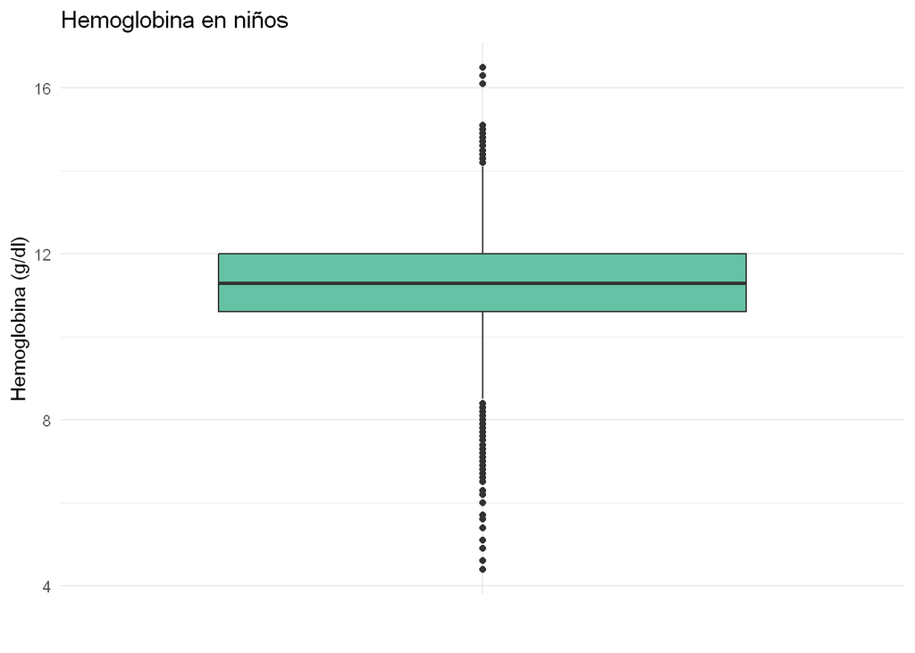

Descriptores numéricos:

| Media | Mediana | Mínimo | Máximo | SD | Q1 | Q3 |
| --- | --- | --- | --- | --- | --- | --- |
| 11.25 | 11.3 | 4.4 | 16.5 | 1.1 | 10.6 | 12 |

#### 3.1.2 Peso de niños

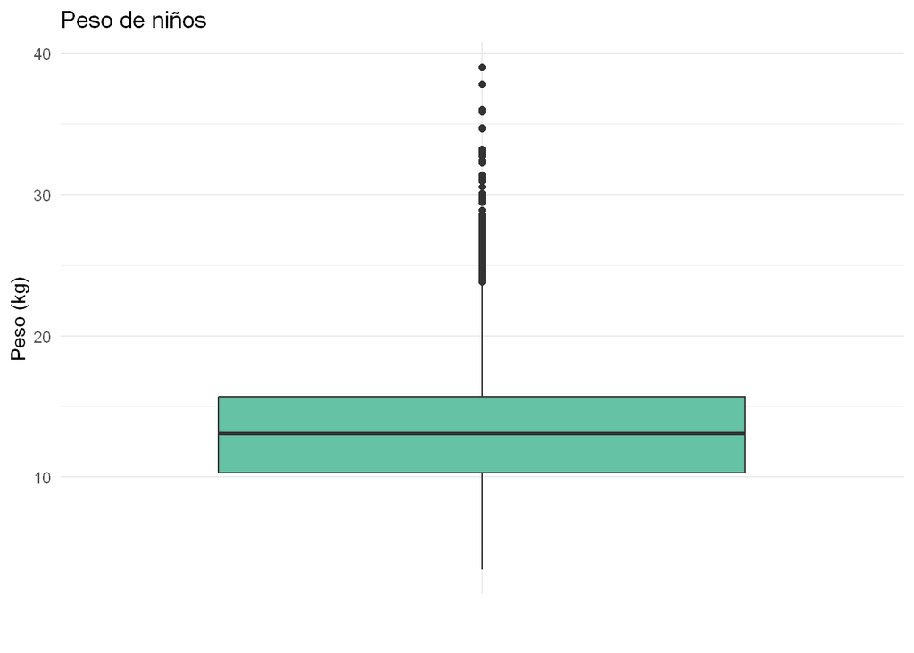

Descriptores numéricos:

| Media | Mediana | Mínimo | Máximo | SD | Q1 | Q3 |
| --- | --- | --- | --- | --- | --- | --- |
| 13.22 | 13.1 | 3.5 | 39 | 3.77 | 10.3 | 15.7 |

#### 3.1.3 Talla de niños

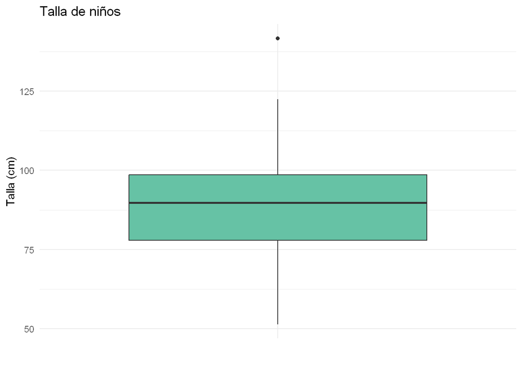

Descriptores numéricos:

| Media | Mediana | Mínimo | Máximo | SD | Q1 | Q3 |
| --- | --- | --- | --- | --- | --- | --- |
| 88.2 | 89.8 | 51.4 | 141.7 | 12.87 | 77.9 | 98.6 |

#### 3.1.4 Hemoglobina de mujeres

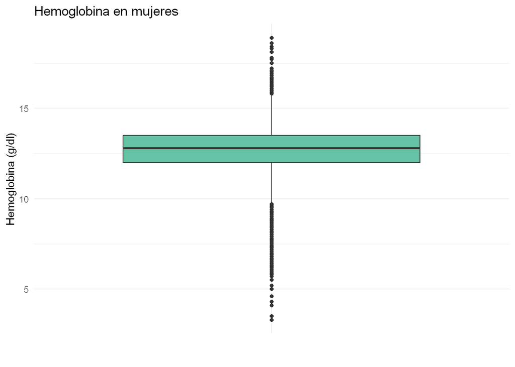

Descriptores numéricos:

| Media | Mediana | Mínimo | Máximo | SD | Q1 | Q3 |
| --- | --- | --- | --- | --- | --- | --- |
| 12.69 | 12.8 | 3.3 | 18.9 | 1.27 | 12 | 13.5 |

#### 3.1.5 Peso de mujeres

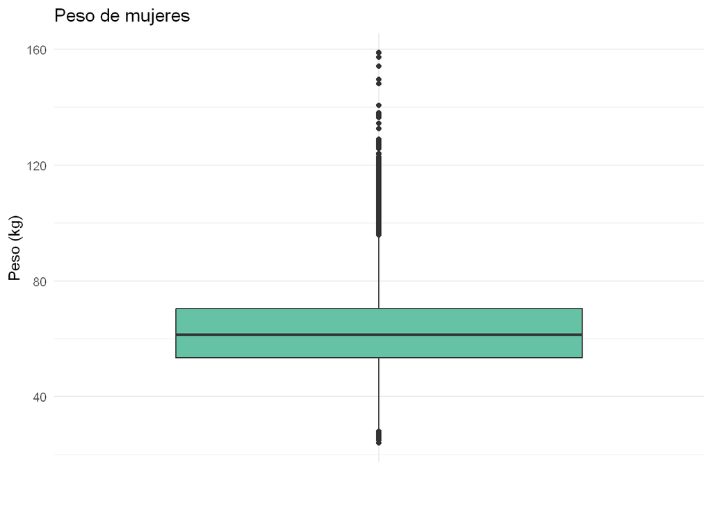

Descriptores numéricos:

| Media | Mediana | Mínimo | Máximo | SD | Q1 | Q3 |
| --- | --- | --- | --- | --- | --- | --- |
| 62.73 | 61.5 | 24.1 | 158.9 | 13.29 | 53.5 | 70.4 |

#### 3.1.6 Talla de mujeres

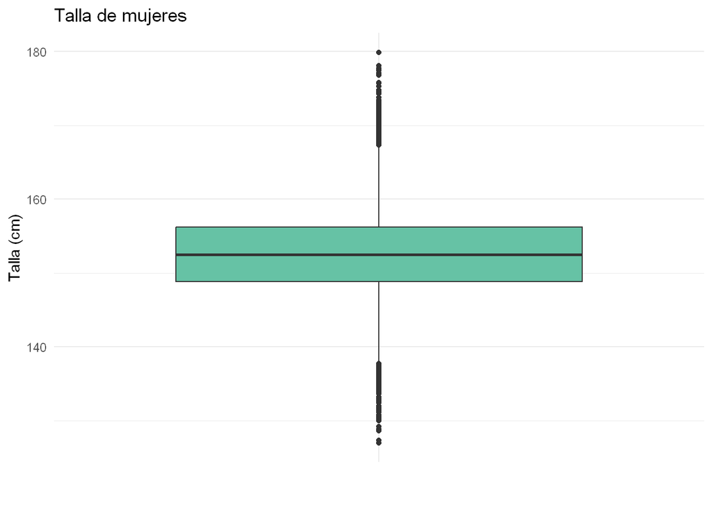

Descriptores numéricos:

| Media | Mediana | Mínimo | Máximo | SD | Q1 | Q3 |
| --- | --- | --- | --- | --- | --- | --- |
| 152.54 | 152.5 | 127 | 179.9 | 5.67 | 148.8 | 156.2 |

### 3.2 Variables categóricas

Las siguientes gráficas están orientadas a nuestro primer objetivo: “**Describir los casos de anemia y su severidad en niños y mujeres en el Perú en el año 2022**”.

#### 3.2.1 Nivel de anemia en niños

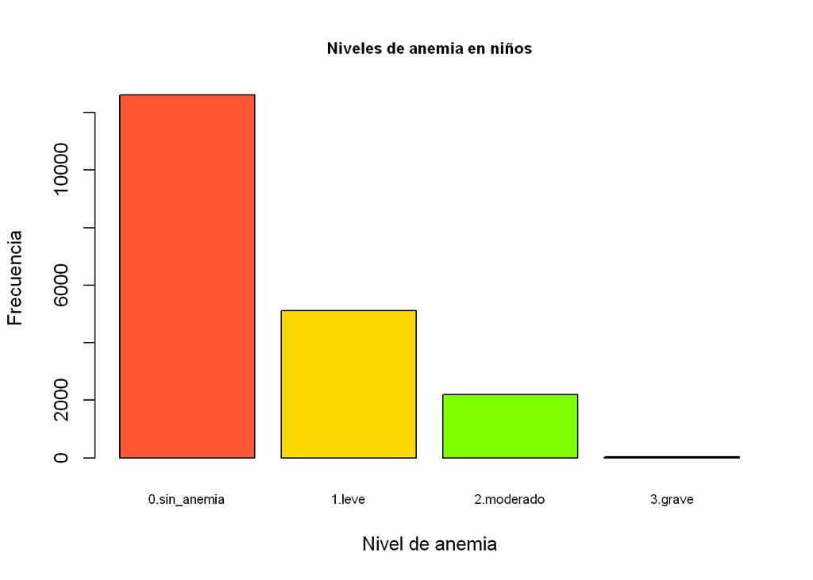

#### 3.2.2 Nivel de anemia en mujeres

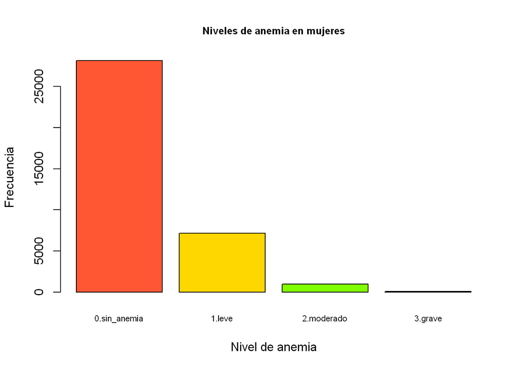

## 4. Análisis descriptivo de interacción

### 4.1 Edad de niños vs. frecuencias de anemia

#### 4.1.1 Edad de niños vs. frecuencia de anemia leve

Promedios correspondientes a la anemia leve

| Variable | Promedio |
| --- | --- |
| edad | 28.00763 |
| peso | 12.20270 |
| talla | 84.82376 |
| estado_medicion | 0.00000 |
| hemoglobina | 11.41234 |
| estado_medicion_hemoglobina | 0.00000 |
| hemoglobina_ajustada_latitud | 10.51752 |

Promedios correspondientes a la anemia moderada

| Variable | Promedio |
| --- | --- |
| edad | 19.91996 |
| peso | 10.62542 |
| talla | 78.36248 |
| estado_medicion | 0.00000 |
| hemoglobina | 10.38763 |
| estado_medicion_hemoglobina | 0.00000 |
| hemoglobina_ajustada_latitud | 9.27417 |

Promedios correspondientes a la anemia grave

| Variable | Promedio |
| --- | --- |
| edad | 17.740741 |
| peso | 9.659259 |
| talla | 76.103704 |
| estado_medicion | 0.000000 |
| hemoglobina | 8.111111 |
| estado_medicion_hemoglobina | 0.000000 |
| hemoglobina_ajustada_latitud | 6.155556 |

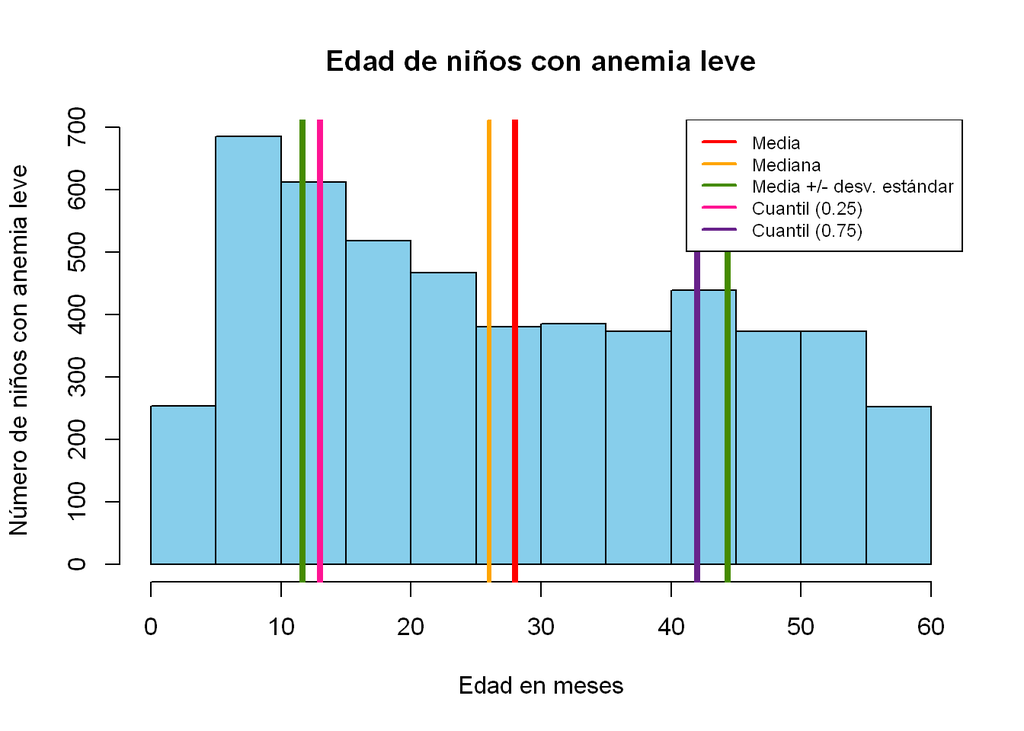

#### 4.1.2 Edad de niños vs. frecuencia de anemia moderada

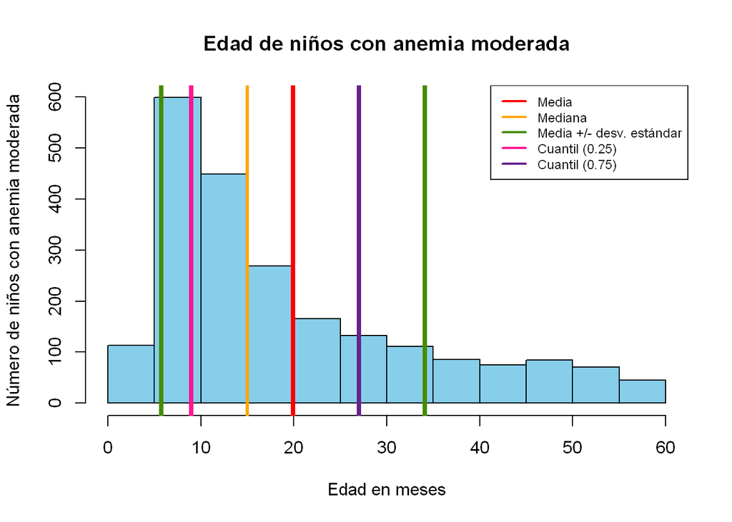

#### 4.1.3 Edad de niños vs. frecuencia de anemia grave

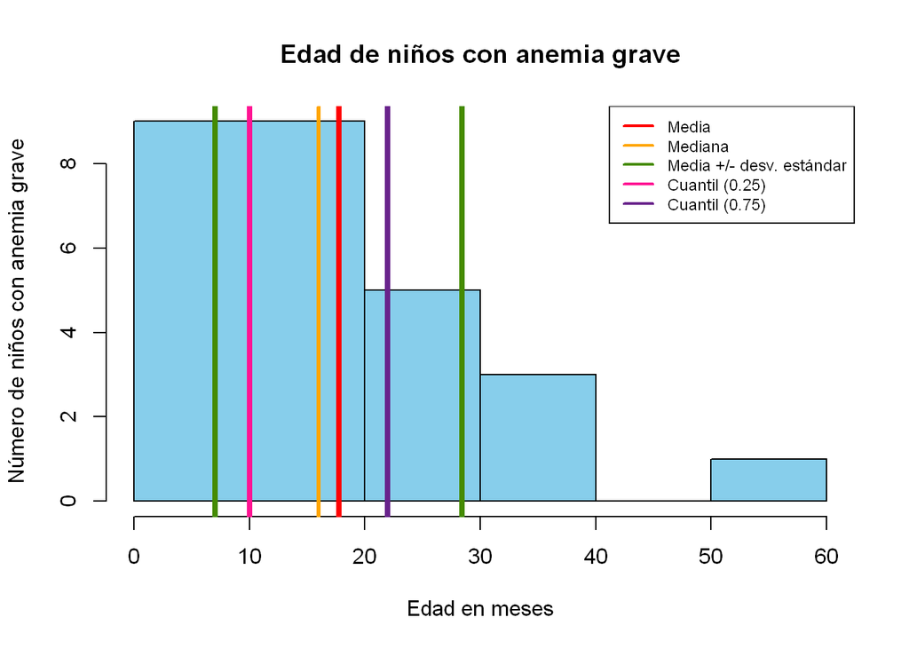

### 4.2 Edad de mujeres vs. frecuencia de anemia

Promedios correspondientes a la anemia leve

| Variable | Promedio |
| --- | --- |
| edad | 27.8790255 |
| peso | 60.5611453 |
| talla | 152.2731028 |
| estado_medicion | 0.0000000 |
| hemoglobina | 12.1322319 |
| is_embarazada | 0.0264632 |
| estado_medicion_hemoglobina | 0.0000000 |
| hemoglobina_ajustada_latitud | 11.3004761 |
| nivel_educativo | 1.8779053 |

Promedios correspondientes a la anemia moderada

| Variable | Promedio |
| --- | --- |
| edad | 30.387526 |
| peso | 62.473108 |
| talla | 152.708691 |
| estado_medicion | 0.000000 |
| hemoglobina | 9.984254 |
| is_embarazada | 0.093047 |
| estado_medicion_hemoglobina | 0.000000 |
| hemoglobina_ajustada_latitud | 9.043967 |
| nivel_educativo | 1.912065 |

Promedios correspondientes a la anemia grave

| Variable | Promedio |
| --- | --- |
| edad | 33.1566265 |
| peso | 60.3915663 |
| talla | 151.6927711 |
| estado_medicion | 0.0000000 |
| hemoglobina | 7.6277108 |
| is_embarazada | 0.0843373 |
| estado_medicion_hemoglobina | 0.0000000 |
| hemoglobina_ajustada_latitud | 6.2060241 |
| nivel_educativo | 1.9397590 |

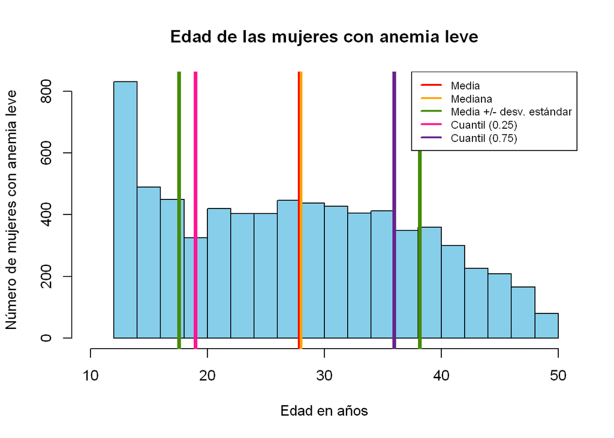

#### 4.2.2 Edad de mujeres vs. frecuencia de anemia moderada

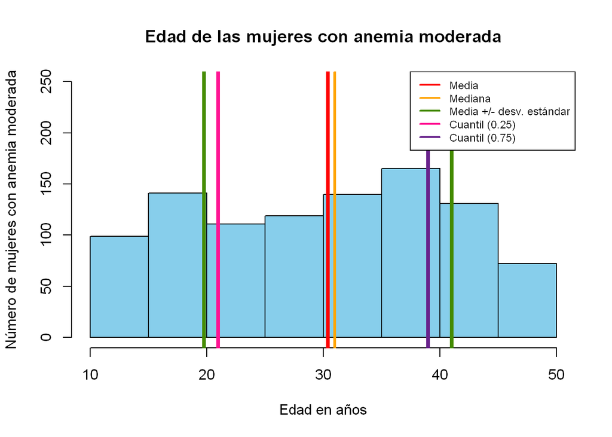

#### 4.2.3 Edad de mujeres vs. frecuencia de anemia grave

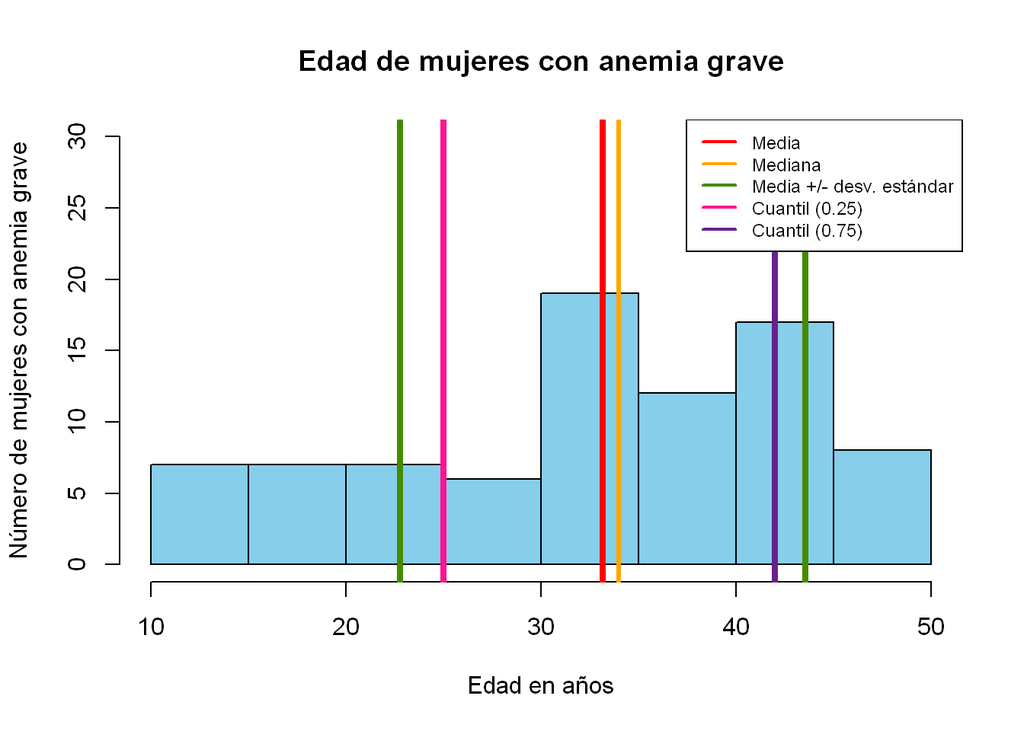

Las siguientes gráficas están orientadas a nuestro segundo objetivo: “**Analizar el índice de anemia en las diversas regiones del Perú en el año 2022**”.

### 4.3 Regiones vs. nivel de anemia

#### 4.3.1 Regiones vs. nivel de anemia en niños

Gráfico donde se tomen las tres regiones con más casos en infantes para luego compararlos.

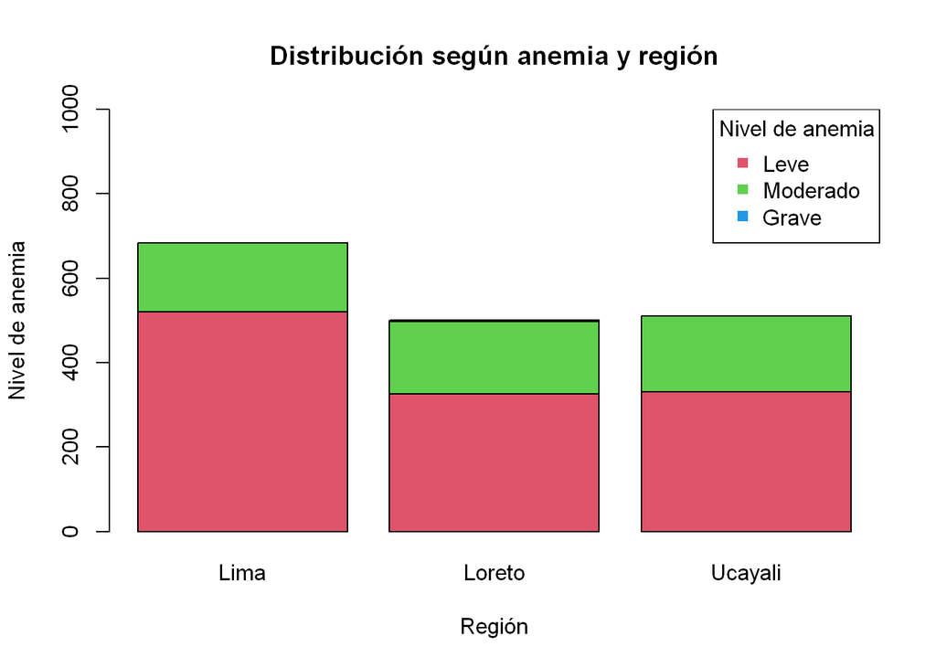

#### 4.3.2 Regiones vs. nivel de anemia en mujeres

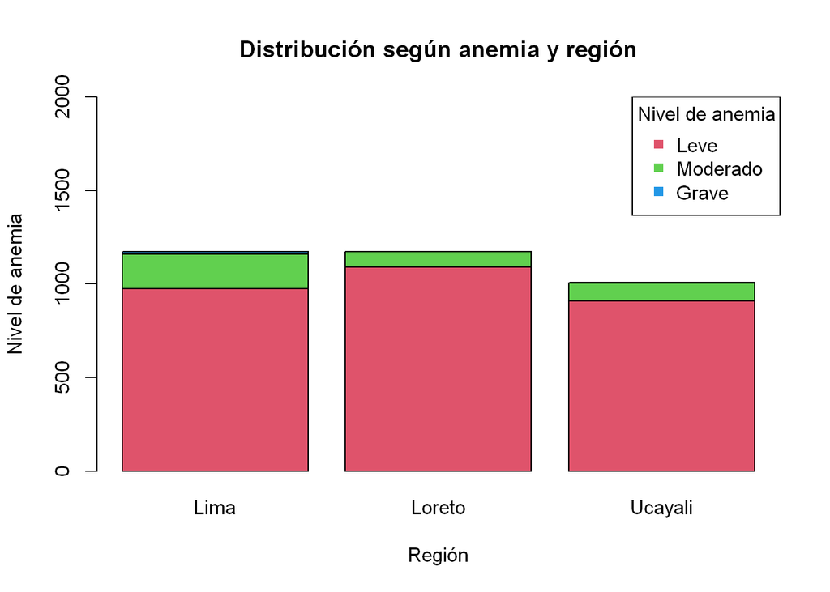

Claramente, se observa una tendencia visible en los tres casos, donde los casos leves son consistentemente predominantes. La elección de focalizar en las tres regiones con mayor incidencia de casos se fundamenta en la necesidad de dirigir mayores esfuerzos y recursos para combatir la enfermedad. Estas regiones identificadas no solo presentan una mayor incidencia, sino que también pueden ser consideradas como puntos críticos que demandan una atención prioritaria en las estrategias de prevención y control de la anemia.

Las siguientes gráficas están orientadas a nuestro tercer objetivo: “**Describir las características sociales de los grupos vulnerables (niños y mujeres) a la anemia en el Perú en el año 2022**”.

### 4.4 Características sociales

#### 4.4.1 *Boxplots* entre hemoglobina e índice de riqueza de las mujeres

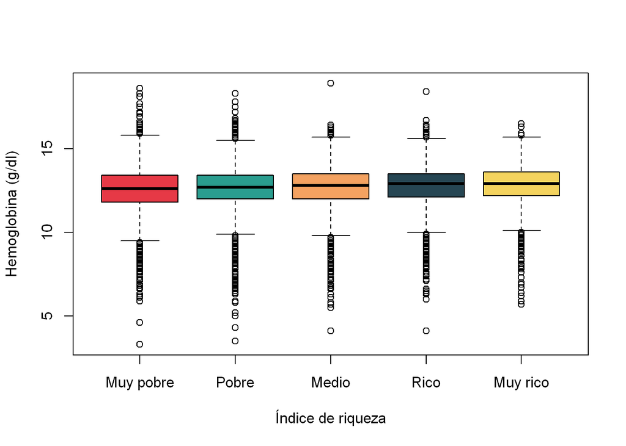

No hay mucha distinción en los casos bajos de hemoglobina por cada separación —que indica si se presenta anemia—.

#### 4.4.2 Tipo de residencia vs. nivel de anemia en niños

|  | 1.leve | 2.moderado | 3.grave |
| --- | --- | --- | --- |
| rural | 1891 | 967 | 13 |
| urbano | 3223 | 1232 | 14 |

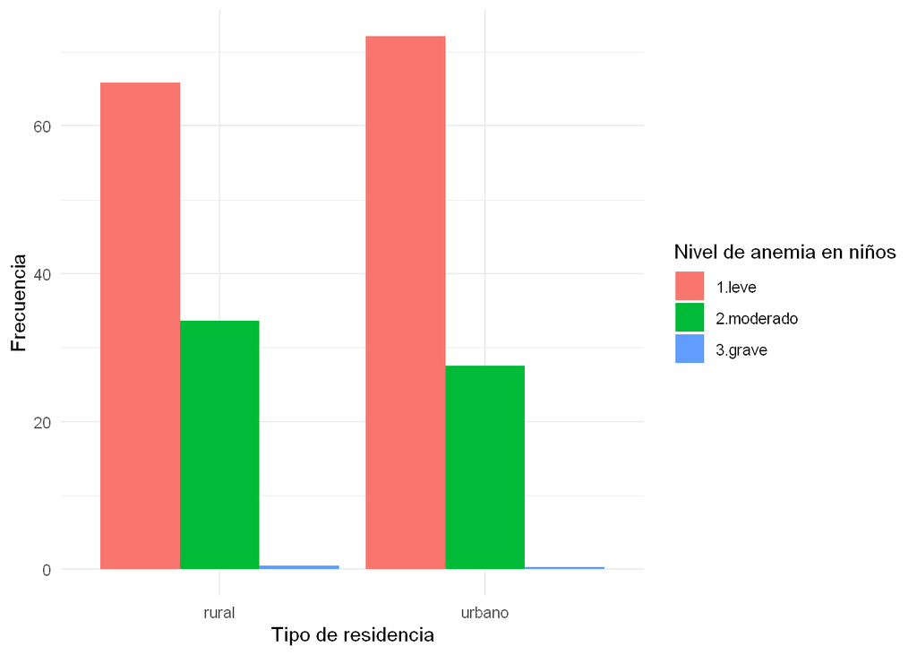

Como podemos observar, la proporción entre los distintos tipos de anemia es bastante similar sea el tipo de residencia urbano o rural.

## 5. Probabilidad empírica

### 5.1 Variable A: Índice de riqueza

**Experimento 1:** Escoger un hogar que aceptó participar en la encuesta y observar su **índice de riqueza**.

**Espacio muestral (** $\Omega$ **):**

| Unique_Values |
| --- |
| 4.rico |
| 5.muy_rico |
| 3.medio |
| 2.pobre |
| 1.muy_pobre |

$$\Omega = E1, \; E2, \; E3, \; E4, \; E5$$

**Eventos atómicos**:

- $E1$: Que se escoja un hogar cuyo índice de riqueza sea muy pobre
- $E2$: Que se escoja un hogar cuyo índice de riqueza sea pobre
- $E3$: Que se escoja un hogar cuyo índice de riqueza sea medio
- $E4$: Que se escoja un hogar cuyo índice de riqueza sea rico
- $E5$: Que se escoja un hogar cuyo índice de riqueza sea muy rico

**Probabilidad de cada evento:**

$$P(x) = \dfrac{f(x)}{n}$$

$f(x)$ = número de veces que se cumpla el evento en toda la muestra

$n$ = tamaño de la muestra

Probabilidad del índice de riqueza

| Índice de riqueza | Probabilidad |
| --- | --- |
| 1.muy_pobre | 0.3150637 |
| 2.pobre | 0.2510422 |
| 3.medio | 0.1867001 |
| 4.rico | 0.1395003 |
| 5.muy_rico | 0.1076937 |

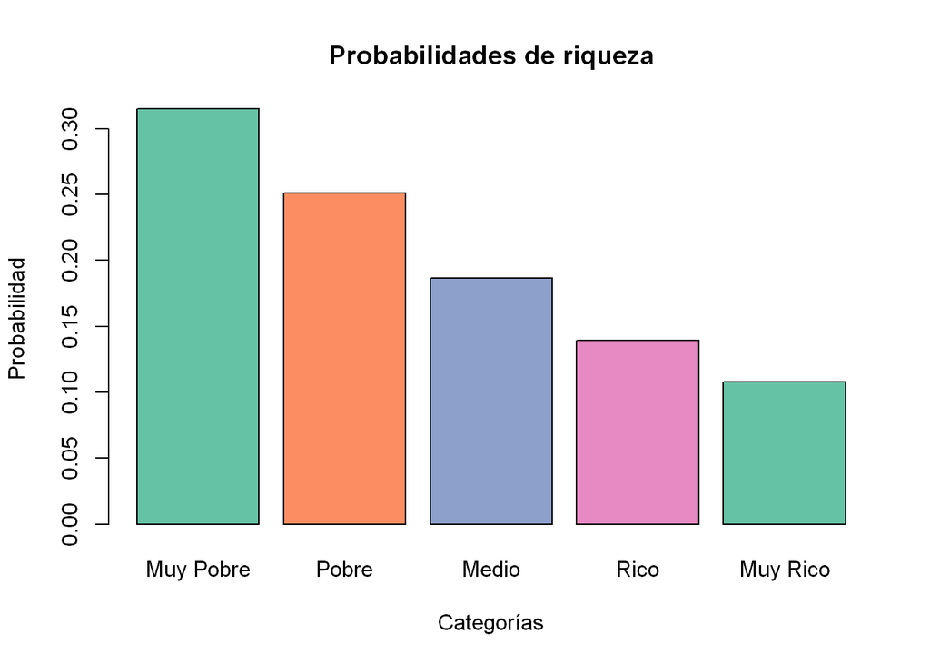

Comprobamos que todo sume uno (ya que son probabilidades de eventos atómicos en un espacio muestral $\Omega$ ).

Suma de probabilidades del índice de riqueza

| Suma de probabilidades |
| --- |
| 1 |

P(**E1**) = 0.3151

P(**E2**) = 0.251

P(**E3**) = 0.1867

P(**E4**) = 0.1395

Determinamos el índice de riqueza con mayor y menor probabilidad de ser escogido:

Valores de Máximo y Mínimo de prob_riqueza

|  | Valor |
| --- | --- |
| 1.muy_pobre | 0.3150637 |
| 5.muy_rico | 0.1076937 |

Al elegir un hogar para el experimento, es más probable que sea muy pobre y menos probable que sea muy rico.

### 5.2 Variable B: Nivel de anemia

**Experimento 2:** Seleccionar a un niño de entre los hogares que han aceptado participar en la prueba de hemoglobina y evaluar su **nivel de anemia**.

**Espacio muestral (** $\Omega$ **):**

Valores únicos de anemia

| Valores_unicos |
| --- |
| 0.sin_anemia |
| 1.leve |
| 2.moderado |
| 3.grave |

$$\Omega = E1, \; E2, \; E3, \; E4$$

**Eventos atómicos**:

**E1**: Que se escoja un infante participante que no tenga anemia.

**E2**: Que se escoja un infante participante cuyo nivel de anemia sea bajo.

**E3**: Que se escoja un infante participante cuyo nivel de anemia sea moderado.

**E4**: Que se escoja un infante participante cuyo nivel de anemia sea alto.

**Probabilidad por evento:**

Probabilidad de Anemia

| Anemia | Probabilidad |
| --- | --- |
| 0.sin_anemia | 0.6321724 |
| 1.leve | 0.2562766 |
| 2.moderado | 0.1101979 |
| 3.grave | 0.0013530 |

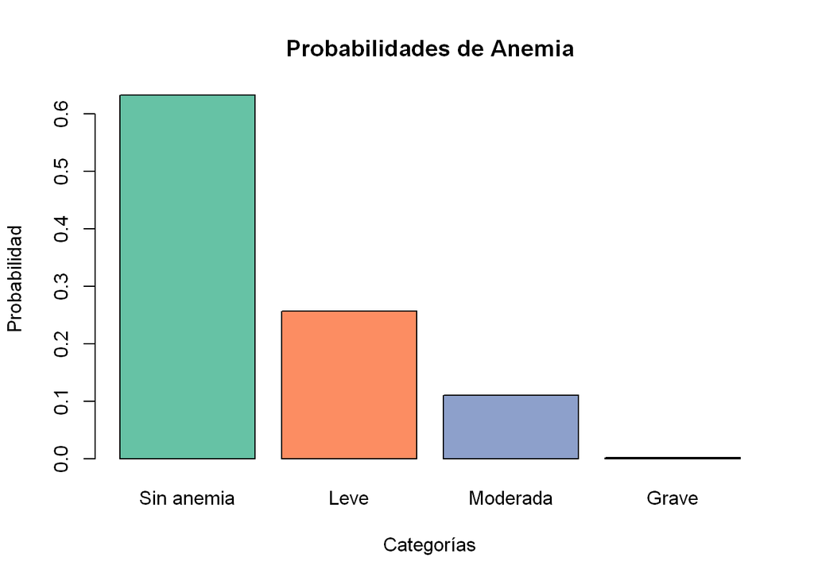

Comprobamos que todo sume uno.

```
[1] 1
```

Probabilidad de cada evento atómico:

P(**E1**) = 0.6322

P(**E2**) = 0.2563

P(**E3**) = 0.1102

P(**E4**) = 0.0014

Nivel de anemia con mayor y menor probabilidad de ser escogida:

```
[1] "0.sin_anemia"
```

```
[1] "3.grave"
```

Es más probable que, entre los niños seleccionados, uno no presente anemia y sea menos probable que esté en un estado grave de la misma.

## 6. Probabilidad condicional

### 6.1 Eventos dependientes

- **A1**: Seleccionar una mujer de la muestra que esté embarazada.
- **A2**: Seleccionar una mujer de la muestra que no esté embarazada.

Probabilidad del evento **A1**:

```
    0     1
35397   971
```

```
[1] 0.0266993
```

Probabilidad del evento **A2**:

```
[1] 0.9733007
```

Vamos a probar que ambos eventos son **dependientes**, comprobando que son mutuamente excluyentes.

Probabilidad que ocurra **A1** y **A2**.

```
[1] 0
```

$$P(A1 \cap A2) = 0$$

Vemos que la intersección de ambos elementos es igual a cero. Al no haber intersección entre ambos eventos, se comprueba que son eventos dependientes.

Dado que ambos eventos son mutuamente excluyentes y abarcan todo el espacio muestral de un experimento, estamos tratando con una partición. En este contexto, podemos aplicar el teorema de la probabilidad total para analizar la situación.

**Teorema de la probabilidad total**:

$$P(B) = P(B \mid A1)*P(A1) + P(B \mid A2)*P(A2)$$

Vamos a tomar un evento que pueda ocurrir en ambos. Este será el evento **B**, que representará si la mujer seleccionada tiene como mayor nivel educativo alcanzado la secundaria.

Probabilidad de que ocurra **B**:

```
[1] 0.650077
```

Observación:

$$P(x \mid y)*P(y) = P(x \cap y)$$

```
Probabilidad total de B encontrada gracias al teorema de probabilidad total: 0.650077
```

```
Probabilidad empírica de B: 0.650077
```

```
Las probabilidades coinciden.
```

Por ser una partición, también se puede comprobar el teorema de Bayes.

**Teorema de Bayes**:

$$P(A \mid B) = \frac{P(B \mid A)*P(A)}{P(B)}$$

```
[1] 0.02863548
```

$$P(A1 \mid B) = 0.02863548$$

La probabilidad de que la mujer escogida resulte embarazada dado que su máximo nivel educativo alcanzado es la secundaria es 0.02863548.

```
[1] 0.9713645
```

$$P(A2 \mid B) = 0.9713645$$

Se puede concluir que la probabilidad de que la mujer escogida no esté embarazada dado que su máximo nivel educativo alcanzado es la secundaria es 0.9713645.

### 6.2 Eventos independientes

- **B1**: Seleccionar un niño que tenga anemia dado que vive en un lugar urbano.
- **B2**: Seleccionar un niño que tenga anemia dado que vive en un lugar rural.

Probabilidad del evento **B1**:

```
[1] 0.3293294
```

Probabilidad del evento **B2**:

```
[1] 0.4496476
```

Vamos a verificar la independencia de los eventos comparando la intersección manual de eventos con el producto de sus probabilidades. Según la regla, si dos eventos son independientes, el producto de sus probabilidades debe ser igual a la intersección de los eventos.

$$P(B1 \cap B2) = P(B1)*P(B2)$$

Intersección de los eventos obtenidos con combinatorias:

```
[1] 0.1480822
```

Producto de las probabilidades de ambos eventos:

```
[1] 0.1480822
```

Al observar que ambos resultados son iguales, podemos concluir que los dos eventos son independientes. Dado que son eventos independientes, podemos realizar las siguientes comprobaciones:

$$P(B1 \mid B2) = B1$$

```
[1] 0.3293294
```

```
[1] 0.3293294
```

$$P(B2 \mid B1) = B2$$

```
[1] 0.4496476
```

```
[1] 0.4496476
```

$$P(B1 \cap B2^c) = P(B1) * P(B2^c)$$

```
[1] 0.1812472
```

```
[1] 0.1812472
```

$$P(B1^c \cap B2^c) = P(B1^c) * P(B2^c)$$

```
[1] 0.3691052
```

```
[1] 0.3691052
```

## 7. Variables aleatorias discretas

### 7.1 Número de niños con un determinado nivel de anemia

```
0.sin_anemia       1.leve   2.moderado      3.grave
       12615         5114         2199           27
```

La variable “**Número de niños con un determinado nivel de anemia”** es discreta, ya que cuenta con precisión cuántos niños se encuentran en cada categoría de anemia (sin anemia, leve, moderado, grave). La discreción proviene de que los valores son enteros y específicos.

Tenemos los siguientes eventos:

**L**: Seleccionar a un niño con anemia cuyo nivel sea clasificado como leve.

**M**: Seleccionar a un niño con anemia cuyo nivel sea clasificado como moderado.

**G**: Seleccionar a un niño con anemia cuyo nivel sea clasificado como grave.

Vamos a tomar el evento **G** como nuestro éxito.

```
Probabilidad de anemia leve (PL): 0.6967302
```

```
Probabilidad de anemia moderada (PM): 0.2995913
```

```
Probabilidad de anemia grave (PG): 0.003678474
```

La probabilidad de ocurra nuestro éxito (**G**):

$$P(G) = 0.0037$$

- **Definimos nuestra variable aleatoria discreta**

**X**: Número de niños observados hasta encontrar el primer caso de anemia grave.

- **Vamos a utilizar el modelo geométrico**

$$X\sim G(p)$$

- **Definimos parámetros**

**p**: Probabilidad que el niño tenga anemia grave.

Observemos un gráfico de distribución geométrica en torno a nuestra variable aleatoria discreta ’**X’**:

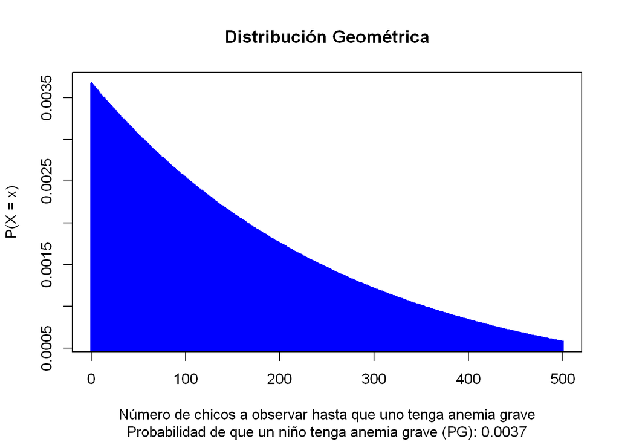

- **Validamos las propiedades de esperanza, varianza, desviación estándar y coeficiente de variación**

```
Media teórica (modelo geométrico): 271.8519
```

```
Varianza teórica (modelo geométrico): 73631.58
```

```
Desviación estándar teórica (modelo geométrico): 271.3514
```

```
Coeficiente de variación teórico (modelo geométrico): 0.9981591
```

```
Media práctica (modelo geométrico): 271.8519
```

```
Varianza práctica (modelo geométrico): 73631.58
```

```
Desviación estándar práctica (modelo geométrico): 271.3514
```

```
Coeficiente de variación práctico (modelo geométrico): 0.9981591
```

Los resultados teóricos y prácticos en el modelo geométrico coinciden, demostrando la eficacia del modelo para describir el número de niños observados hasta encontrar uno con anemia grave. La coherencia en estos indicadores estadísticos respalda la validez de la aproximación geométrica en este contexto.

- **Experimento**

Se quiere averiguar la probabilidad de que se necesite observar 100 niños o menos para encontrar uno con anemia grave.

$$P(X \leq 100)$$

```
[1] 0.3082465
```

La probabilidad de que se necesite observar 100 niños o menos para encontrar uno con anemia grave es de aproximadamente 0.3082465.